# Red wine quality dataset exploration and summary by Mohamed Zeghlache

### alcohol

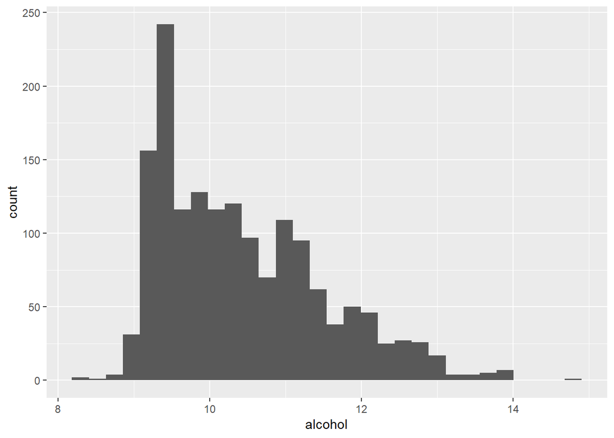

this histogram is skewed to the right.

### quality

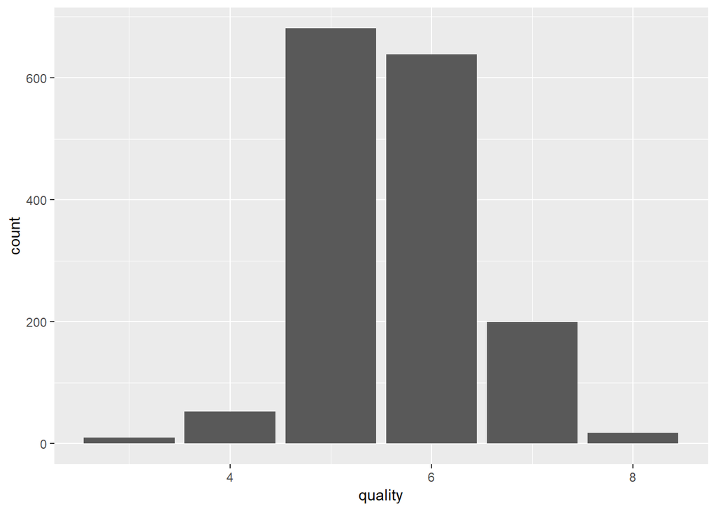

this bar plot shows the distribution of the quality values, it looks like the quality of the red wine is between 3 and 8.with most of the red wine having a quality of 5 or 6.

# Univariate Analysis

### What is the structure of your dataset?

the red wine dataset contains 12 attributes(variables), 11 of them are numerical values for chemical tests made on the wine, and the last attribute is the output of those chemical tests(the quality). and it consists of 1599 observations.

### What is/are the main feature(s) of interest in your dataset?

clearly, the main feature of interest in the dataset is the quality.

### What other features in the dataset do you think will help support your investigation into your feature(s) of interest?

all the other 11 features may have an effect over the quality because the quality depends on them. although, they might have different levels of correlation to the quality.

### Did you create any new variables from existing variables in the dataset?

No, i did not.

### Of the features you investigated, were there any unusual distributions? Did you perform any operations on the data to tidy, adjust, or change the form of the data? If so, why did you do this?

There were no unusual distributions. i did not perform any operations to tidy the data, it’s already tidy. I’ve just dropped a column because it represented the index of the rows which is “redundant”.

# Bivariate Plots Section

we’ll first start by drawing a correlation chart of all the variables

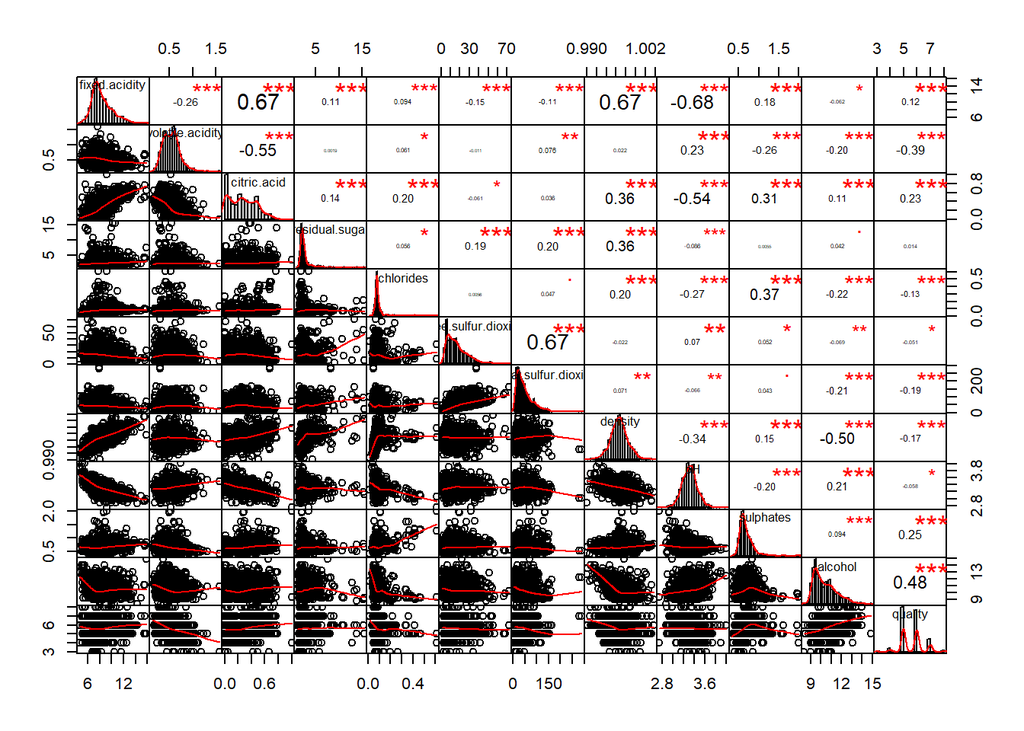

on this plot we can see the distributions of all the variables on the diagonal, and we can also see the scatter plots of different variable below the diagram, and on top of the diagram we can see the significance and correletion between the variables.

### volatile.acidity vs quality

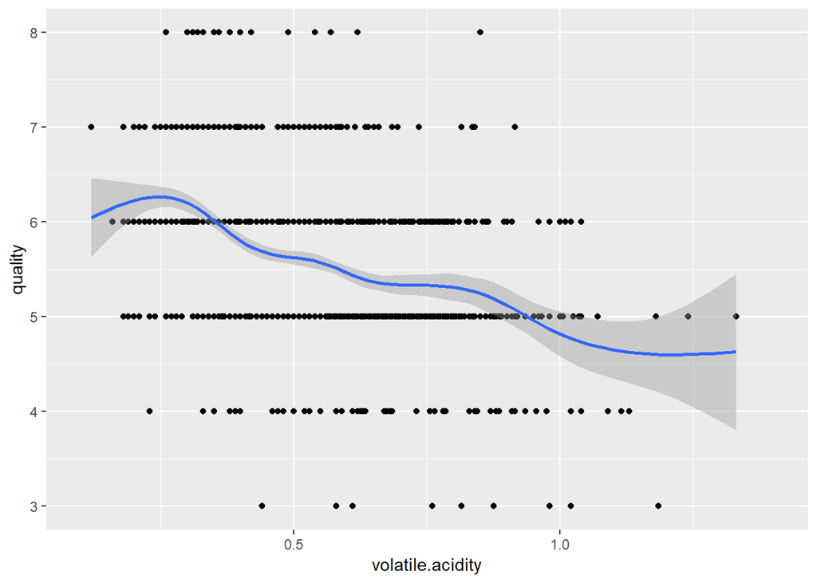

we can see that there is a small correlation between the volatile.acidity and the quality, as the volatile.acidity increases the quality decreases.with only on outlier that i have eliminated from the plot.

### alcohol vs quality

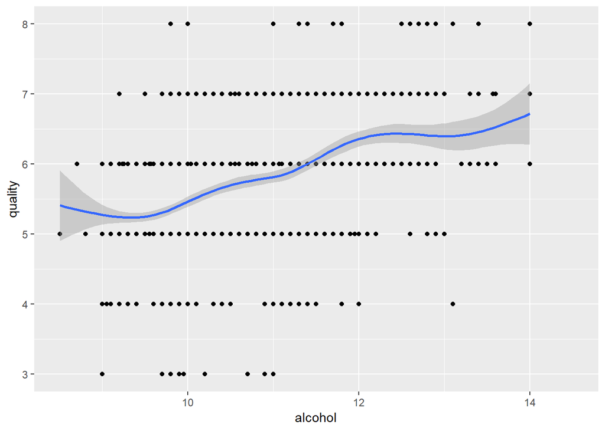

we can see that there is a small correlation between the alcohol and the quality, as the alcohol increases the quality also increases, with only on outlier that i have eliminated from the plot.

### fixed.acidity vs density

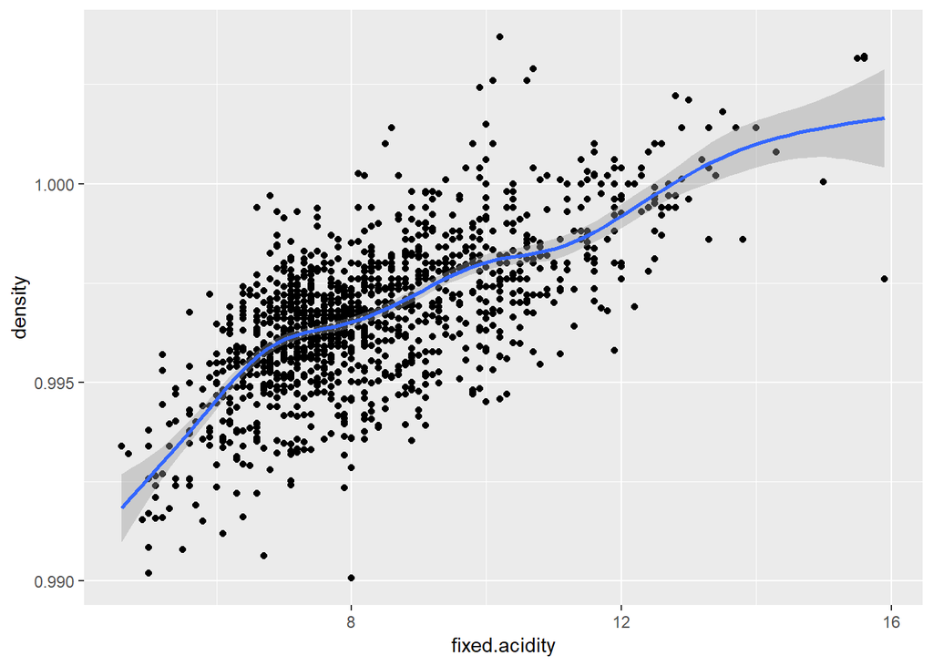

we can also notice that there is a strong correlation between the fixed.acidity and the density of the wine.

### fixed.acidity vs pH

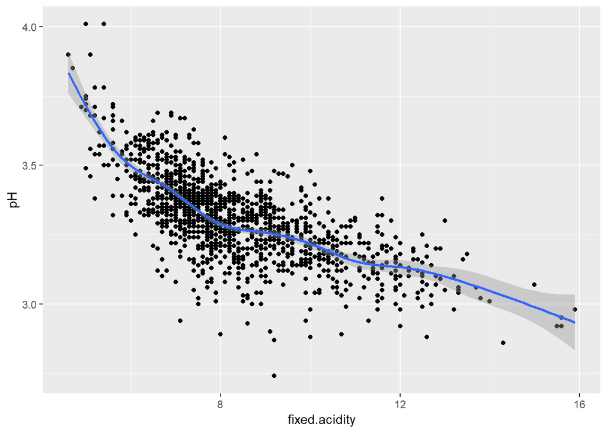

we can also notice that there is a strong negative correlation between the fixed.acidity and the pH of the wine.

# Bivariate Analysis

### Did you observe any interesting relationships between the other features (not the main feature(s) of interest)?

yeah, there were some strong correlation test scores between other features as (fixed.acidity vs pH) and (fixed.acidity vs density)

### What was the strongest relationship you found?

the strongest relationship i found was (fixed.acidity vs pH)

# Multivariate Plots Section

> **Tip**: Now it’s time to put everything together. Based on what you found in the bivariate plots section, create a few multivariate plots to investigate more complex interactions between variables. Make sure that the plots that you create here are justified by the plots you explored in the previous section. If you plan on creating any mathematical models, this is the section where you will do that.

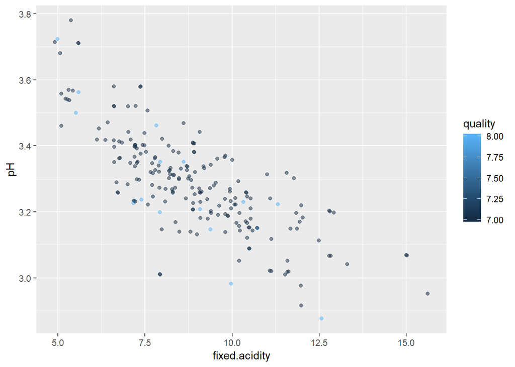

i can’t see a clear pattern for the high quality wine’s relationship to pH and fixed.acidity.

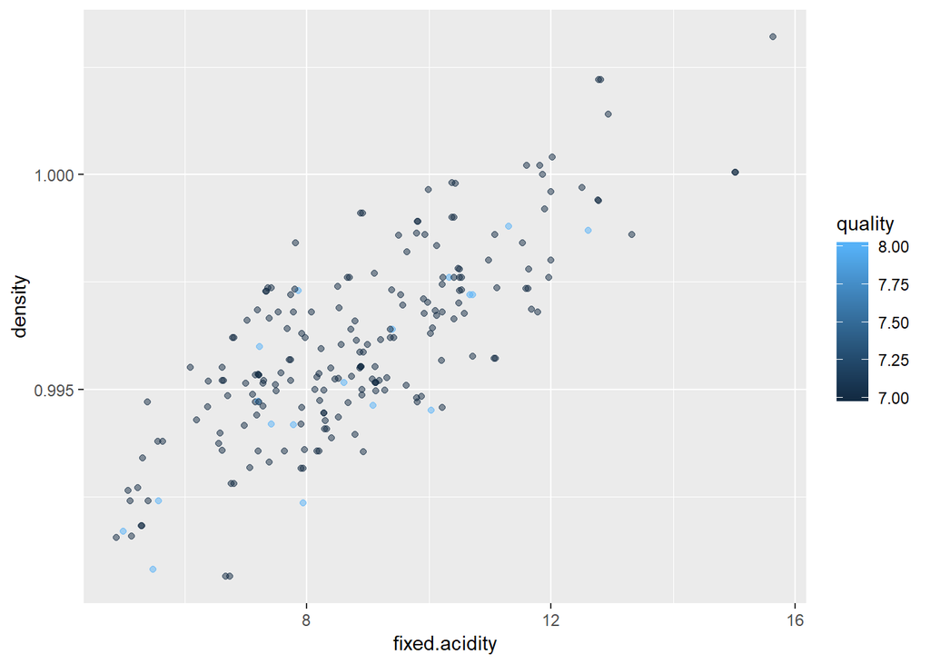

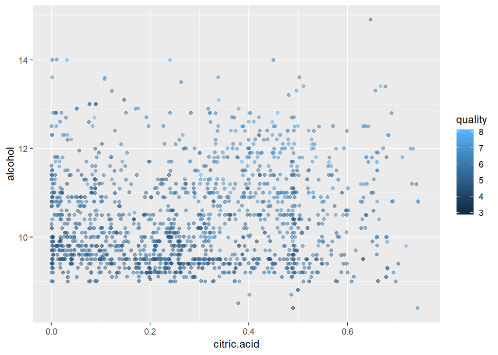

the increase of both alcohol and citric acid results in an increase in th quality of red wine.

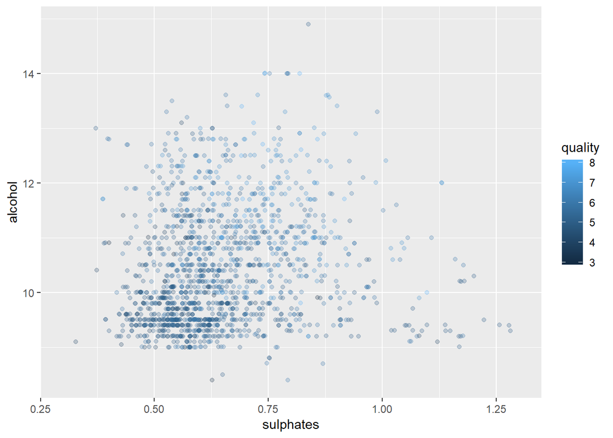

# Multivariate Analysis

### Talk about some of the relationships you observed in this part of the investigation. Were there features that strengthened each other in terms of looking at your feature(s) of interest?

yeah, i think that the citric acid and the alcohol stregthen each other, and alcohol and sulphates also stregthen each other.

### Were there any interesting or surprising interactions between features?

# Final Plots and Summary

> **Tip**: You’ve done a lot of exploration and have built up an understanding of the structure of and relationships between the variables in your dataset. Here, you will select three plots from all of your previous exploration to present here as a summary of some of your most interesting findings. Make sure that you have refined your selected plots for good titling, axis labels (with units), and good aesthetic choices (e.g. color, transparency). After each plot, make sure you justify why you chose each plot by describing what it shows.

### Plot One

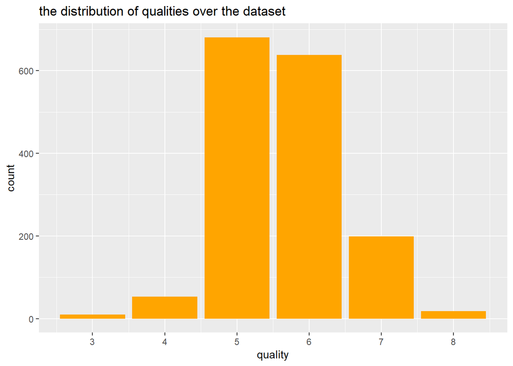

### Description One

this bar plot shows that the quality of the red wine ranges between 3 and 8, but most the red wine in the dataset have a quality of 5 or 6.

### Plot Two

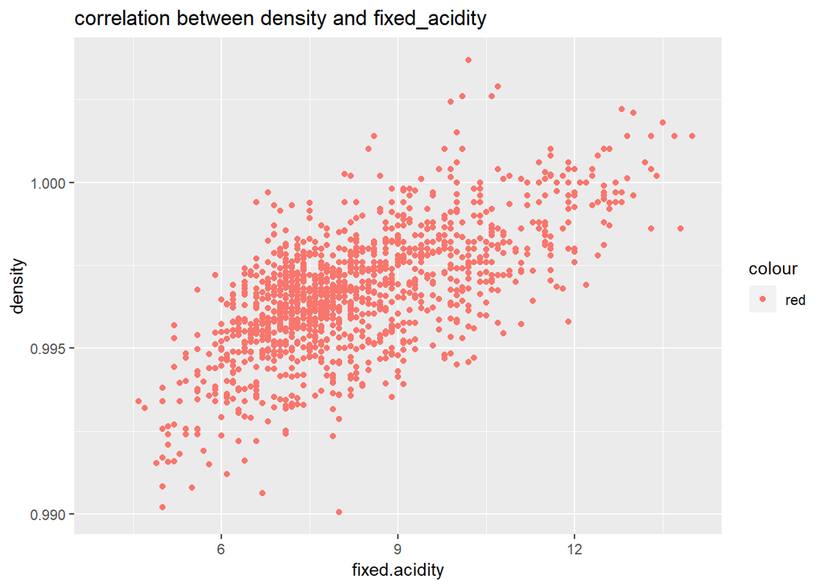

### Description Two

this plot is interesting because we can see how the density and the fixed.acidity strengthen each other. The plot shows a strong positive correlation.

### Plot Three

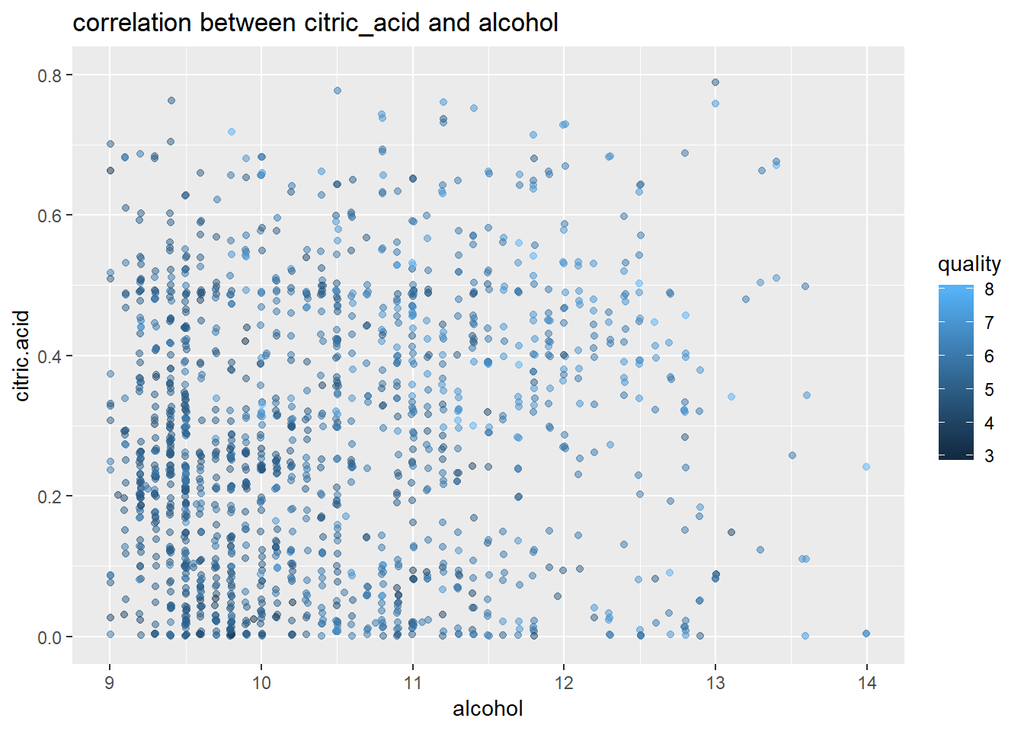

## in this plot we can see that the increase of both alcohol and citric acid results in an increase in the quality of red wine.

# Reflection

this was a very interesting dataset with many variables to explore.

one of the struggles that i went through is deciding if any variable really had a significant effect on the quality of the wine, because the dataset didn’t have many high quality wine samples(unbalanced).

for me, drawing the bar chart had a very usefel impact on defining a path of the exploration of this dataset.

i think that a future work that could be done with the dataset is to give all of the wine samples the same alcohol value and see if the distribution of the quality in the dataset will have a significant change.